# Part II - What is the role of the family plays in the student academic success?

## by Dingdong Li

## Investigation Overview

In this project, I want to look at how the immigration status, family structure and parents education and occupation status can affect the students' academic performance in the United States.  
We found that the parents educational level and occupational status play important roles in students' academic success, and the family structure will influence the relationship between students' academic performance and highest occupational status of parents.

## Dataset Overview

The dataset that I analysed is the OECD’s Programme for International Student Assessment 2012 survey dataset (PISA2012). The survey assessed the 15-year-old students' skills and knowledge in mathematics, science and reading. The original PISA2012 dataset has 485,490 rows and 636 columns, but the features used for this analysis includes gender, immigrant background, family Structure, occupational status of parents, parental education in years,out-of-School study time and students' plausible value 1 in mathematics, reading and science.

## Distribution of the math science and reading scores

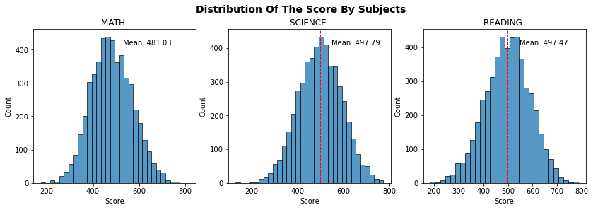

## Distribution of immgration background

The majority of the participants are native, about 700 students are second-generation and 300 students are first-generation.

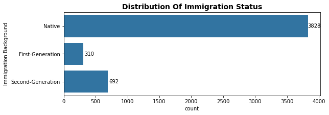

## Distribution of family structure

Most of the students are from two-parents family, about 900 are from single-parents family, very few students are not living with their parents.

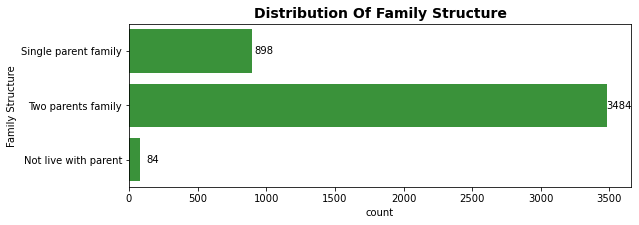

## Distribution of highest educational level of parents

In most of the cases, at least one of the students' parents achieved education of ISCED 5A,6 (theoretically oriented tertiary and post-graduate) and ISCED 3A (general upper secondary)/ISCED 4 (non-tertiary post-secondary) level of education.

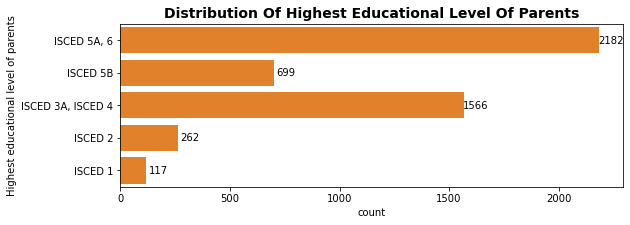

## Distribution of highest occupational status of the parents

The highest occupational status of the parents range from 10 to about 90, is a multimode distrbution.

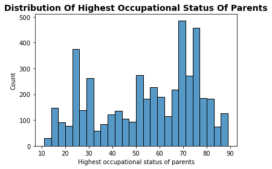

## MATH, SCIENCE and READING score vs. immigration background

The students with different immigration background, their academic performance are not very different from each other, except that the native students seem to slightly better than students who are first or second generation.

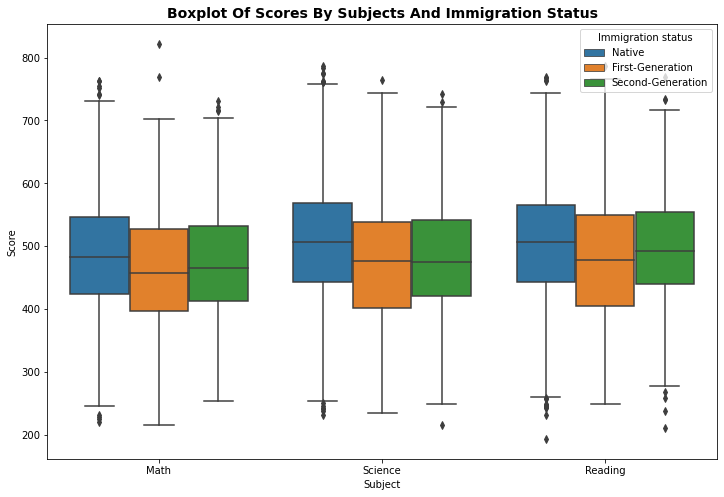

## MATH, SCIENCE and READING scores vs. highest educational level of parents

In general, the students whose parents have higher education tends to have better academic performance in all three subjects.

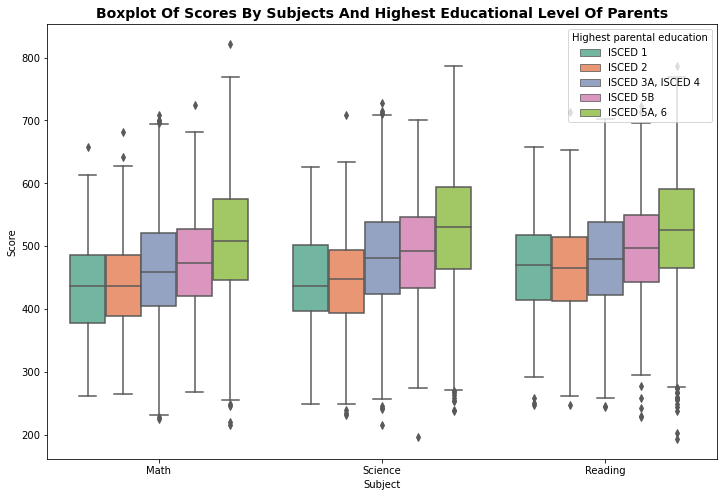

## MATH, SCIENCE and READING score vs. highest parents occupational status

The students' academic performances have moderate positive correlation with the highest occupational status of the parents.

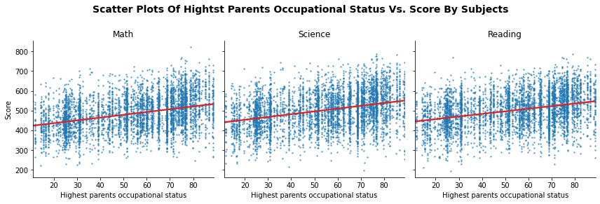

## MATH, SCIENCE and READING score vs. highest parental occupation status with different family structures

The students who do not live together with their parents, the regression line of the highest occupational status of parents vs. students academic performance is almost flat. The slop of the regression line for the two parents family is larger than the regression slope of the single-parents family.

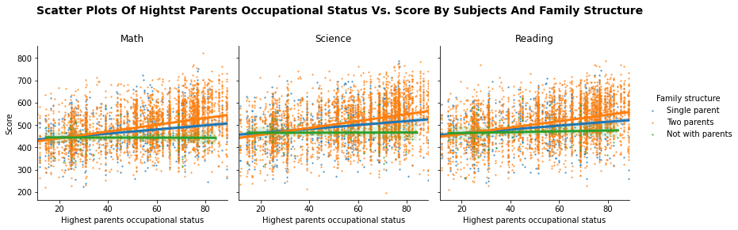